# Analyzing Individual BGG Users

Phil Henrickson

2022-01-02

# **Spiher’s** BoardGameGeek Collection

This notebook contains a set of analyses for the selected user’s boardgamegeek collection. The bulk of the analysis is focused on building a user-specific predictive model to predict the games that Spiher is likely to own. This enables to ask questions like, based on the games the user currently owns, what games are a good fit for their collection? What upcoming games are they likely to purchase?

This analysis is based on data from BoardGameGeek that was last updated on **2021-12-20.**

# 1 Collection Overview

We can look at a basic description of the number of games that the user owns, has rated, has previously owned, etc.

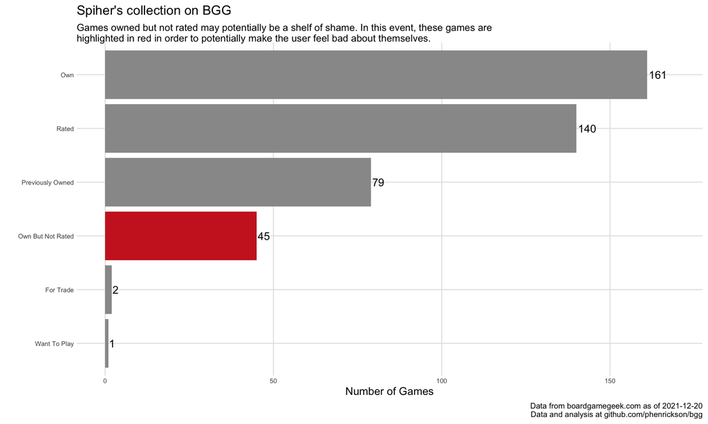

What years has the user owned/rated games from? While we can’t see when a user added or removed a game from their collection, we can look at their collection by the years in which their games were published.

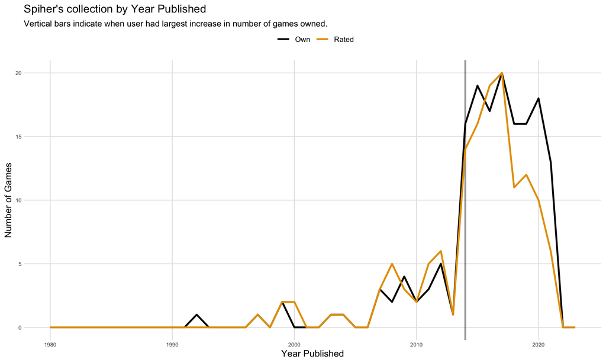

## 1.1 What types of games does Spiher own?

We can look at the most frequent types of categories, mechanics, designers, and artists that appear in a user’s collection.

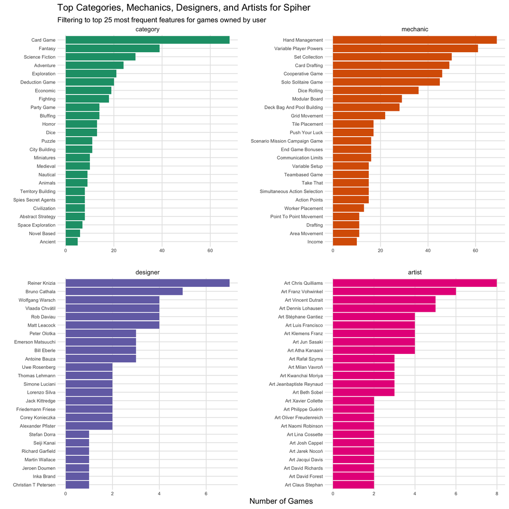

# 2 Modeling **Spiher’s** Collection

| username | dataset | period | games_owned | games_rated | games_played |
| --- | --- | --- | --- | --- | --- |
| Spiher | training | published before 2020 | 129 | 123 | 217 |
| Spiher | test | published 2020 or later | 31 | 16 | 37 |

There are two main (binary) outcomes we will be modeling for the user.

The first, **own** refers to whether the user currently lists a game as owned in their collection. The second, **played** refers to whether the user currently owns, has rated, or previously owned a game. This means the latter will generally have a larger list of games, but may still be a useful category to examine for people who play lots of games without necessarily owning them.

We will train predictive models to learn the probability that the user will own or play individual games based on their features.

## 2.1 Coefficients for Spiher

We can examine coefficients from the trained modes, which are penalized logistic regressions fit to our two main outcomes. Positive values indicate that a feature increases a user’s probabilility of owning/rating a game, while negative values indicate a feature decreases the probability.

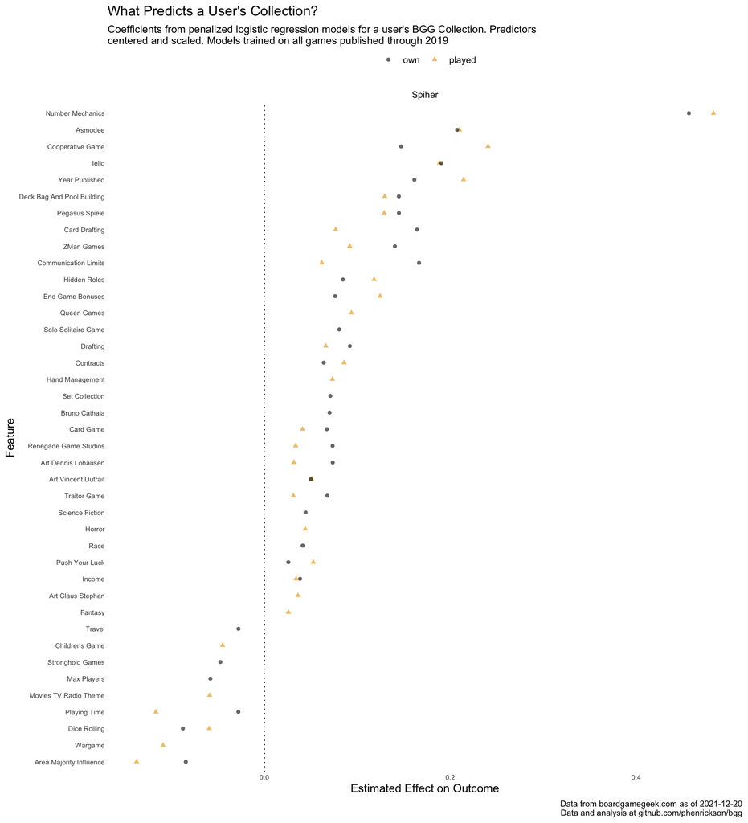

## 2.2 Visualizing Predictors for Spiher’s Collection

Why did the model identify these features? We can make density plots of the important features for predicting whether the user owned a game. Blue indicates the density for games owned by the user, while grey indicates the density for games not owned by the user.

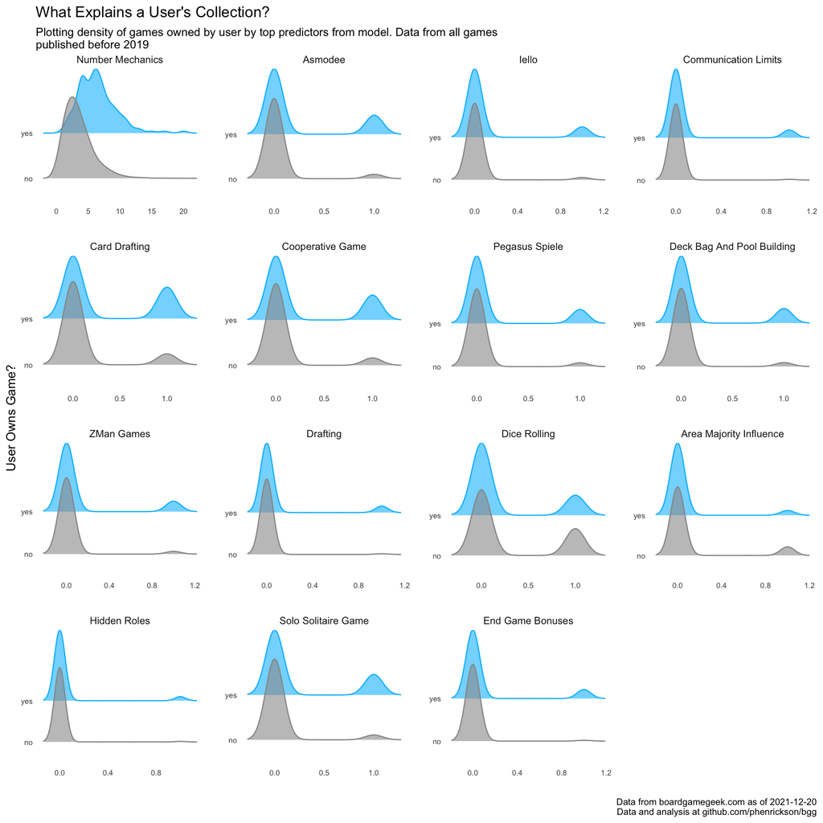

Binary predictors can be difficult to see with this visualization, so we can also directly examine the percentage of games in a user’s collection with a predictor vs the percentage of all games with that predictor.

| username | Feature | % of Games with Feature In_Collection | % of Games with Feature All_Games | Ratio |
| --- | --- | --- | --- | --- |
| Spiher | Communication Limits | 10.1% | 0.8% | 11.9 |
| Spiher | End Game Bonuses | 11.6% | 1.1% | 10.4 |
| Spiher | Income | 6.2% | 0.6% | 9.6 |
| Spiher | Drafting | 8.5% | 0.9% | 9.2 |
| Spiher | Traitor Game | 5.4% | 0.6% | 9.0 |
| Spiher | Hidden Roles | 5.4% | 0.7% | 8.3 |
| Spiher | Contracts | 7.0% | 0.9% | 7.4 |
| Spiher | Renegade Game Studios | 3.9% | 0.8% | 4.6 |
| Spiher | Asmodee | 22.5% | 5.1% | 4.4 |
| Spiher | Iello | 13.2% | 3.0% | 4.4 |
| Spiher | Solo Solitaire Game | 24.0% | 5.6% | 4.3 |
| Spiher | ZMan Games | 13.2% | 3.4% | 3.9 |
| Spiher | Deck Bag And Pool Building | 17.8% | 4.7% | 3.8 |
| Spiher | Pegasus Spiele | 17.1% | 4.6% | 3.7 |
| Spiher | Cooperative Game | 27.9% | 8.3% | 3.4 |
| Spiher | Race | 5.4% | 1.8% | 3.0 |
| Spiher | Card Drafting | 33.3% | 11.6% | 2.9 |
| Spiher | Push Your Luck | 13.2% | 5.2% | 2.5 |
| Spiher | Science Fiction | 17.8% | 8.6% | 2.1 |
| Spiher | Set Collection | 32.6% | 17.4% | 1.9 |
| Spiher | Card Game | 43.4% | 30.9% | 1.4 |
| Spiher | Dice Rolling | 21.7% | 29.0% | 0.7 |
| Spiher | Area Majority Influence | 6.2% | 11.2% | 0.6 |
| Spiher | Stronghold Games | 0.0% | 1.5% | 0.0 |
| Spiher | Travel | 0.0% | 1.2% | 0.0 |

# 3 Assess Model’s Performance on Training Set

Before predicting games in upcoming years, we can examine how well the model did and what games it liked in the training set. In this case, we used resampling techniques (cross validation) to ensure that the model had not seen a game before making its predictions.

## 3.1 Separation Plot

An easy way to examine the performance of classification model is to view a separation plot. We plot the predicted probabilities from the model for every game (from resampling) from lowest to highest. We then overlay a blue line for any game that the user does own. A good classifier is one that is able to *separate* the blue (games owned by the user) from the white (games not owned by the user), with most of the blue occurring at the highest probabilities (right side of the chart).

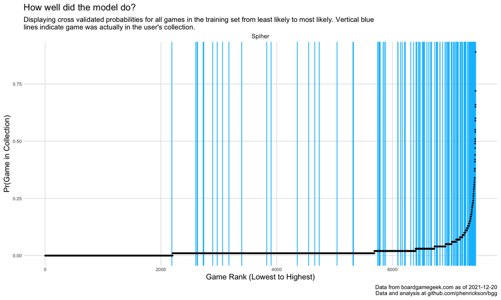

## 3.2 Top Games for **Spiher** from Training Set

We can display this information in table form, displaying the 100 games with the highest probability of ownership, adding a blue line when the user does own the game.

| username | yearpublished | game_id | name | pred_played | pred_own | actual_played | actual_own |
| --- | --- | --- | --- | --- | --- | --- | --- |
| Spiher | 2017 | 174430 | Gloomhaven | 0.93 | 0.89 | 1 | 1 |
| Spiher | 2019 | 283863 | The Magnificent | 0.91 | 0.72 | 0 | 0 |
| Spiher | 2018 | 244711 | Newton | 0.64 | 0.66 | 0 | 0 |
| Spiher | 2016 | 198454 | When I Dream | 0.65 | 0.65 | 0 | 0 |
| Spiher | 2018 | 205896 | Rising Sun | 0.50 | 0.60 | 0 | 0 |
| Spiher | 2011 | 96848 | Mage Knight Board Game | 0.68 | 0.59 | 0 | 0 |
| Spiher | 2000 | 478 | Citadels | 0.56 | 0.55 | 1 | 0 |
| Spiher | 2014 | 156129 | Deception: Murder in Hong Kong | 0.45 | 0.54 | 1 | 1 |
| Spiher | 2019 | 270971 | Era: Medieval Age | 0.85 | 0.51 | 0 | 0 |
| Spiher | 2012 | 121921 | Robinson Crusoe: Adventures on the Cursed Island | 0.50 | 0.50 | 1 | 1 |
| Spiher | 2005 | 15062 | Shadows over Camelot | 0.40 | 0.49 | 0 | 0 |
| Spiher | 2012 | 120677 | Terra Mystica | 0.30 | 0.47 | 0 | 0 |
| Spiher | 2011 | 70919 | Takenoko | 0.70 | 0.44 | 0 | 0 |
| Spiher | 2013 | 140620 | Lewis & Clark: The Expedition | 0.38 | 0.42 | 0 | 0 |
| Spiher | 2009 | 39683 | At the Gates of Loyang | 0.22 | 0.41 | 0 | 0 |
| Spiher | 2017 | 224037 | Codenames: Duet | 0.35 | 0.38 | 1 | 1 |
| Spiher | 2019 | 281259 | The Isle of Cats | 0.20 | 0.38 | 0 | 0 |
| Spiher | 2013 | 127024 | Room 25 | 0.68 | 0.37 | 0 | 0 |
| Spiher | 2016 | 155821 | Inis | 0.14 | 0.34 | 0 | 0 |
| Spiher | 2013 | 52461 | Legacy: The Testament of Duke de Crecy | 0.49 | 0.34 | 0 | 0 |
| Spiher | 2018 | 245928 | Pax Emancipation | 0.42 | 0.33 | 0 | 0 |
| Spiher | 2017 | 188920 | This War of Mine: The Board Game | 0.38 | 0.32 | 0 | 0 |
| Spiher | 2018 | 170604 | Renegade | 0.28 | 0.32 | 0 | 0 |
| Spiher | 2018 | 199792 | Everdell | 0.20 | 0.31 | 0 | 0 |
| Spiher | 2018 | 231327 | The Grizzled: Armistice Edition | 0.18 | 0.31 | 0 | 0 |
| Spiher | 2015 | 181304 | Mysterium | 0.36 | 0.31 | 1 | 1 |
| Spiher | 2019 | 251247 | Barrage | 0.30 | 0.30 | 1 | 0 |
| Spiher | 2017 | 209778 | Magic Maze | 0.23 | 0.30 | 1 | 1 |
| Spiher | 2004 | 9220 | Saboteur | 0.55 | 0.30 | 0 | 0 |
| Spiher | 2010 | 73171 | Earth Reborn | 0.25 | 0.29 | 0 | 0 |

[output cut: 70 more lines]

We can also more formally assess how well the model did in resampling by looking at the area under the receiver operating characteristic. A perfect model would receive a score of 1, while a model that cannot predict the outcome will default to a score of 0.5. The extent to which something is a *good* score depends on the setting, but generally anything in the .8 to .9 range is very good while the .7 to .8 range is perfectly acceptable.

| username | outcome_type | .metric | .estimator | .estimate |
| --- | --- | --- | --- | --- |
| Spiher | own | roc_auc | binary | 0.888 |
| Spiher | played | roc_auc | binary | 0.885 |

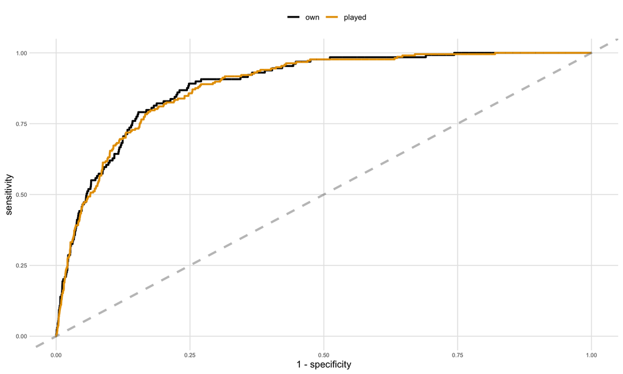

Another way to think about the model performance is to view its lift, or its ability to detect the positive outcomes over that of a null model. High lift indicates the model can much more quickly find all of the positive outcomes (in this case, games owned or played by the user), while a model with no lift is no better than random guessing.

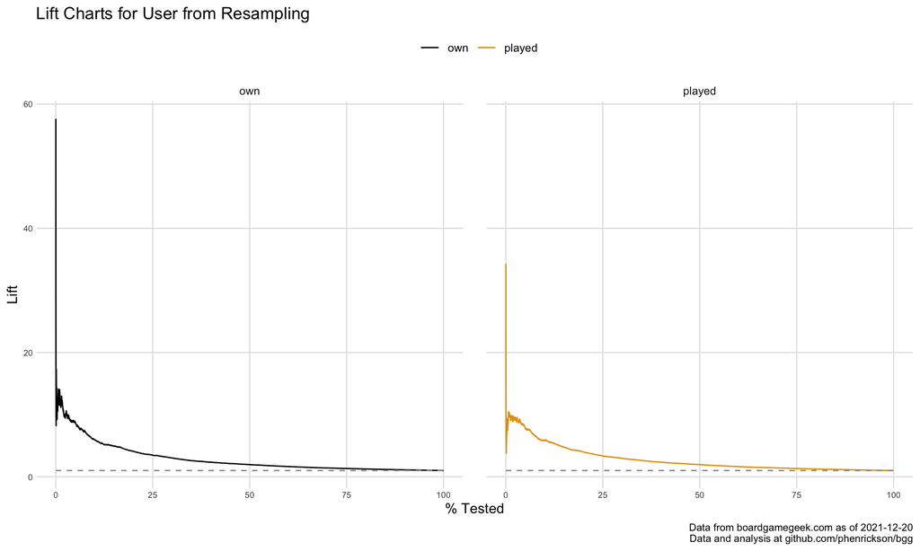

## 3.3 Most and Least Likely Games

What games does the model think Spiher is **most likely to own** that are **not** in their collection?

| username | yearpublished | game_id | name | pred_own | actual_own |
| --- | --- | --- | --- | --- | --- |
| Spiher | 2019 | 283863 | The Magnificent | 0.72 | 0 |
| Spiher | 2018 | 244711 | Newton | 0.66 | 0 |
| Spiher | 2016 | 198454 | When I Dream | 0.65 | 0 |
| Spiher | 2018 | 205896 | Rising Sun | 0.60 | 0 |
| Spiher | 2011 | 96848 | Mage Knight Board Game | 0.59 | 0 |

What games does the model think Spiher is **least likely to own** that **are** in their collection?

| username | yearpublished | game_id | name | pred_own | actual_own |
| --- | --- | --- | --- | --- | --- |
| Spiher | 2019 | 291453 | SCOUT | 0.00 | 1 |
| Spiher | 1999 | 372 | Schotten Totten | 0.01 | 1 |
| Spiher | 2016 | 195544 | Tides of Madness | 0.01 | 1 |
| Spiher | 2019 | 264241 | Mandala | 0.01 | 1 |
| Spiher | 2018 | 225885 | Unbroken | 0.01 | 1 |

## 3.4 Top Games by Year

Top 25 games most likely to be owned by the user in each year, highlighting in blue the games that the user has owned/played.

| rank | 2011 | 2012 | 2013 | 2014 | 2015 | 2016 | 2017 | 2018 | 2019 |
| --- | --- | --- | --- | --- | --- | --- | --- | --- | --- |
| 1 | Mage Knight Board Game | Robinson Crusoe: Adventures on the Cursed Island | Lewis & Clark: The Expedition | Deception: Murder in Hong Kong | Mysterium | When I Dream | Gloomhaven | Newton | The Magnificent |
| 2 | Takenoko | Terra Mystica | Room 25 | Imperial Settlers | Codenames | Inis | Codenames: Duet | Rising Sun | Era: Medieval Age |
| 3 | Mundus Novus | Archipelago | Legacy: The Testament of Duke de Crecy | Legendary Encounters: An Alien Deck Building Game | FUSE | Codenames: Pictures | This War of Mine: The Board Game | Pax Emancipation | The Isle of Cats |
| 4 | Nightfall | Space Cadets | Forbidden Desert | Patchwork | Blood Rage | Black Orchestra | Magic Maze | Renegade | Barrage |
| 5 | Dungeon Fighter | Lords of Waterdeep | Concordia | Spyfall | Raptor | Aeon's End | Breaking Bad: The Board Game | Everdell | Sierra West |
| 6 | Eminent Domain | Targi | Patchistory | Splendor | The Voyages of Marco Polo | Terraforming Mars | Fog of Love | The Grizzled: Armistice Edition | Amul |
| 7 | Village | Smash Up | A Study in Emerald | La Granja | A Study in Emerald (Second Edition) | Beyond Baker Street | Century: Spice Road | Star Realms: Frontiers | It's a Wonderful World |
| 8 | Tragedy Looper | The Resistance: Avalon | Bomb Squad | Witness | Star Realms: Colony Wars | The Oregon Trail Card Game | Gaia Project | Nemesis | The Crew: The Quest for Planet Nine |
| 9 | Nightfall: Martial Law | Love Letter | Sushi Go! | Sheriff of Nottingham | Through the Ages: A New Story of Civilization | Scythe | Codenames: Disney – Family Edition | The Pirate Republic | Aquatica |
| 10 | A Few Acres of Snow | Keyflower | Pathfinder Adventure Card Game: Rise of the Runelords – Base Set | Star Realms | The Game | A Feast for Odin | Mountains of Madness | Pandemic: Fall of Rome | Clank!: Legacy – Acquisitions Incorporated |
| 11 | Principato | Escape: The Curse of the Temple | BANG! The Dice Game | Ultimate Werewolf | Mombasa | Pandemic: Reign of Cthulhu | Pandemic Legacy: Season 2 | Cahoots | Maracaibo |
| 12 | Flash Point: Fire Rescue | Il Vecchio | The Ravens of Thri Sahashri | Camel Up | ...and then, we held hands. | Dead of Winter: The Long Night | Paper Tales | Decrypto | The King's Dilemma |
| 13 | Ninjato | Zombicide | City of Remnants | Sheep & Thief | The Big Book of Madness | Kanagawa | Mythic Battles: Pantheon | Azul: Stained Glass of Sintra | Tainted Grail: The Fall of Avalon |
| 14 | Discworld: Ankh-Morpork | Rumble in the Dungeon | Tash-Kalar: Arena of Legends | Alchemists | Sylvion | Citadels | Azul | Narabi | Last Bastion |
| 15 | Pastiche | Yedo | Eight-Minute Empire: Legends | Pandemic: The Cure | Tales & Games: Little Red Riding Hood | Hit Z Road | Too Many Bones | Century: Eastern Wonders | The Lord of the Rings: Journeys in Middle-Earth |
| 16 | Ascension: Return of the Fallen | Descent: Journeys in the Dark (Second Edition) | Smash Up: Awesome Level 9000 | Onirim (Second Edition) | One Night Ultimate Werewolf: Daybreak | Dream Home | Pulsar 2849 | Dungeon Alliance | Noctiluca |
| 17 | Ascension: Storm of Souls | Star Trek Deck Building Game: The Next Generation – Next Phase | Glass Road | Abyss | Tiny Epic Galaxies | The Oracle of Delphi | Ex Libris | Château Aventure | Tiny Towns |
| 18 | Panic Station | Seasons | Impulse | One Night Ultimate Werewolf | The Grizzled | Pandemic: Iberia | Dragonfire | Duelosaur Island | One Key |
| 19 | King of Tokyo | Pax Porfiriana | Hanamikoji | Five Tribes | Pandemic Legacy: Season 1 | 13 Days: The Cuban Missile Crisis | The Shipwreck Arcana | Who Goes There? | Aeon's End: Legacy |
| 20 | The New Era | Uchronia | The Witches: A Discworld Game | King of New York | Baseball Highlights: 2045 | Sushi Go Party! | Bunny Kingdom | Hardback | Obscurio |
| 21 | Dungeon Petz | Suburbia | Ultimate Werewolf: Inquisition | Fields of Arle | Dead Men Tell No Tales | Yokohama | Century: Golem Edition | Blackout: Hong Kong | Ragusa |
| 22 | The Gnomes of Zavandor | The Manhattan Project | Tajemnicze Domostwo | Port Royal | Brick Party | Pathfinder Adventure Card Game: Mummy's Mask – Base Set | Smash Up: What Were We Thinking? | Founders of Gloomhaven | Aerion |
| 23 | Gears of War: The Board Game | Urbion | SOS Titanic | Yardmaster Express | Burgle Bros. | The Networks | First Martians: Adventures on the Red Planet | Shadows: Amsterdam | Spire's End |
| 24 | Alcatraz: The Scapegoat | Mice and Mystics | Smash Up: The Obligatory Cthulhu Set | Heroes of Normandie | The Pursuit of Happiness | Archaeology: The New Expedition | XenoShyft: Dreadmire | Muse: Awakenings | Chai |
| 25 | Resident Evil Deck Building Game: Alliance | Legends of Andor | Hoplomachus: Rise of Rome | Castles of Mad King Ludwig | Dale of Merchants | Assembly | Downforce | Street Masters | Minecraft: Builders & Biomes |

## 3.5 Interactive Predictions from Resampling

Interactive table for predictions from resampling.

|  | username | yearpublished | rank | game_id | name | pred_played | pred_own | actual_played | actual_own |
| --- | --- | --- | --- | --- | --- | --- | --- | --- | --- |
| 1 | Spiher | 1900 | 4018 | 15878 | Rummy | 0.01 | 0.01 | 0 | 0 |
| 2 | Spiher | 1900 | 4220 | 2136 | Pachisi | 0 | 0.01 | 0 | 0 |
| 3 | Spiher | 1900 | 4222 | 2386 | Chinese Checkers | 0 | 0.01 | 0 | 0 |
| 4 | Spiher | 1900 | 5245 | 5546 | Marbles | 0 | 0 | 0 | 0 |
| 5 | Spiher | 1900 | 5248 | 11901 | Tic-Tac-Toe | 0 | 0 | 0 | 0 |
| 6 | Spiher | 1900 | 5266 | 188 | Go | 0 | 0 | 0 | 0 |
| 7 | Spiher | 1900 | 5327 | 171 | Chess | 0 | 0 | 0 | 0 |
| 8 | Spiher | 1900 | 5330 | 2065 | Shogi | 0 | 0 | 0 | 0 |
| 9 | Spiher | 1900 | 5331 | 2393 | Xiangqi | 0 | 0 | 0 | 0 |
| 10 | Spiher | 1900 | 5398 | 26952 | International Checkers | 0 | 0 | 0 | 0 |

[output cut: 7426 more lines]

# 4 Validating the Model on 2020

How well did a model trained on a user’s collection through 2019 perform in predicting games for the user from 2020?

| username | outcome_type | yearpublished | .metric | .estimator | .estimate |
| --- | --- | --- | --- | --- | --- |
| Spiher | own | 2020 | roc_auc | binary | 0.856 |
| Spiher | played | 2020 | roc_auc | binary | 0.850 |

Table of top 25 games from 2020, highlighting games that the user owns.

| username | yearpublished | game_id | name | pred_own | pred_played | actual_own | actual_played |
| --- | --- | --- | --- | --- | --- | --- | --- |
| Spiher | 2020 | 291457 | Gloomhaven: Jaws of the Lion | 0.77 | 0.76 | 1 | 1 |
| Spiher | 2020 | 184267 | On Mars | 0.64 | 0.74 | 0 | 1 |
| Spiher | 2020 | 256317 | Guild Master | 0.38 | 0.69 | 0 | 0 |
| Spiher | 2020 | 292333 | Cowboys II: Cowboys & Indians Edition | 0.36 | 0.59 | 0 | 0 |
| Spiher | 2020 | 307844 | Atheneum: Mystic Library | 0.27 | 0.38 | 0 | 0 |
| Spiher | 2020 | 316554 | Dune: Imperium | 0.23 | 0.15 | 0 | 0 |
| Spiher | 2020 | 296151 | Viscounts of the West Kingdom | 0.20 | 0.21 | 0 | 0 |
| Spiher | 2020 | 300322 | Hallertau | 0.20 | 0.44 | 0 | 0 |
| Spiher | 2020 | 301767 | Mysterium Park | 0.18 | 0.17 | 0 | 1 |
| Spiher | 2020 | 288169 | The Fox in the Forest Duet | 0.16 | 0.14 | 0 | 0 |
| Spiher | 2020 | 312484 | Lost Ruins of Arnak | 0.15 | 0.18 | 1 | 1 |
| Spiher | 2020 | 313698 | Monster Expedition | 0.15 | 0.21 | 0 | 0 |
| Spiher | 2020 | 314040 | Pandemic Legacy: Season 0 | 0.15 | 0.27 | 1 | 1 |
| Spiher | 2020 | 316377 | 7 Wonders (Second Edition) | 0.15 | 0.18 | 0 | 0 |
| Spiher | 2020 | 262274 | D6: Dungeons, Dudes, Dames, Danger, Dice and Dragons! | 0.13 | 0.30 | 0 | 0 |
| Spiher | 2020 | 288513 | Tranquility | 0.13 | 0.12 | 0 | 0 |
| Spiher | 2020 | 306735 | Under Falling Skies | 0.12 | 0.15 | 1 | 1 |
| Spiher | 2020 | 323784 | Ghost Letters | 0.12 | 0.14 | 0 | 0 |
| Spiher | 2020 | 246900 | Eclipse: Second Dawn for the Galaxy | 0.11 | 0.12 | 0 | 0 |
| Spiher | 2020 | 300531 | Paleo | 0.11 | 0.19 | 1 | 1 |
| Spiher | 2020 | 320819 | Dinner in Paris | 0.11 | 0.24 | 0 | 0 |
| Spiher | 2020 | 262939 | Far Away | 0.10 | 0.08 | 0 | 0 |
| Spiher | 2020 | 284742 | Honey Buzz | 0.10 | 0.13 | 0 | 0 |
| Spiher | 2020 | 301919 | Pandemic: Hot Zone – North America | 0.10 | 0.21 | 0 | 0 |
| Spiher | 2020 | 299317 | Aeon's End: Outcasts | 0.09 | 0.16 | 1 | 1 |

# 5 Predicting Upcoming Games (2020 and On) for **Spiher**

Examine the top games for the test set.

| username | yearpublished | game_id | name | rank | own | played |
| --- | --- | --- | --- | --- | --- | --- |
| Spiher | 2020 | 291457 | Gloomhaven: Jaws of the Lion | 1 | 0.77 | 0.76 |
| Spiher | 2020 | 184267 | On Mars | 2 | 0.64 | 0.74 |
| Spiher | 2020 | 256317 | Guild Master | 3 | 0.38 | 0.69 |
| Spiher | 2020 | 292333 | Cowboys II: Cowboys & Indians Edition | 4 | 0.36 | 0.59 |
| Spiher | 2020 | 307844 | Atheneum: Mystic Library | 5 | 0.27 | 0.38 |
| Spiher | 2020 | 316554 | Dune: Imperium | 6 | 0.23 | 0.15 |
| Spiher | 2020 | 296151 | Viscounts of the West Kingdom | 7 | 0.20 | 0.21 |
| Spiher | 2020 | 300322 | Hallertau | 8 | 0.20 | 0.44 |
| Spiher | 2020 | 301767 | Mysterium Park | 9 | 0.18 | 0.17 |
| Spiher | 2020 | 288169 | The Fox in the Forest Duet | 10 | 0.16 | 0.14 |
| Spiher | 2020 | 314040 | Pandemic Legacy: Season 0 | 11 | 0.15 | 0.27 |
| Spiher | 2020 | 316377 | 7 Wonders (Second Edition) | 12 | 0.15 | 0.18 |
| Spiher | 2020 | 313698 | Monster Expedition | 13 | 0.15 | 0.21 |
| Spiher | 2020 | 312484 | Lost Ruins of Arnak | 14 | 0.15 | 0.18 |
| Spiher | 2020 | 288513 | Tranquility | 15 | 0.13 | 0.12 |
| Spiher | 2020 | 262274 | D6: Dungeons, Dudes, Dames, Danger, Dice and Dragons! | 16 | 0.13 | 0.30 |
| Spiher | 2020 | 306735 | Under Falling Skies | 17 | 0.12 | 0.15 |
| Spiher | 2020 | 323784 | Ghost Letters | 18 | 0.12 | 0.14 |
| Spiher | 2020 | 246900 | Eclipse: Second Dawn for the Galaxy | 19 | 0.11 | 0.12 |
| Spiher | 2020 | 300531 | Paleo | 20 | 0.11 | 0.19 |
| Spiher | 2020 | 320819 | Dinner in Paris | 21 | 0.11 | 0.24 |
| Spiher | 2020 | 262939 | Far Away | 22 | 0.10 | 0.08 |
| Spiher | 2020 | 301919 | Pandemic: Hot Zone – North America | 23 | 0.10 | 0.21 |
| Spiher | 2020 | 284742 | Honey Buzz | 24 | 0.10 | 0.13 |
| Spiher | 2020 | 299592 | Beez | 25 | 0.09 | 0.19 |
| Spiher | 2021 | 298102 | Roll Camera!: The Filmmaking Board Game | 1 | 0.75 | 0.61 |
| Spiher | 2021 | 310873 | Carnegie | 2 | 0.42 | 0.61 |
| Spiher | 2021 | 291847 | Mantis Falls | 3 | 0.41 | 0.63 |
| Spiher | 2021 | 342942 | Ark Nova | 4 | 0.36 | 0.36 |
| Spiher | 2021 | 291859 | Riftforce | 5 | 0.25 | 0.27 |
| Spiher | 2021 | 283387 | Rocketmen | 6 | 0.24 | 0.32 |
| Spiher | 2021 | 324856 | The Crew: Mission Deep Sea | 7 | 0.21 | 0.21 |
| Spiher | 2021 | 333553 | For the King (and Me) | 8 | 0.20 | 0.24 |
| Spiher | 2021 | 249277 | Brazil: Imperial | 9 | 0.18 | 0.25 |
| Spiher | 2021 | 344277 | Corrosion | 10 | 0.18 | 0.19 |
| Spiher | 2021 | 280984 | Ruins: Death Binder | 11 | 0.16 | 0.30 |
| Spiher | 2021 | 319999 | Dungeon Decorators | 12 | 0.16 | 0.35 |
| Spiher | 2021 | 251661 | Oathsworn: Into the Deepwood | 13 | 0.15 | 0.41 |
| Spiher | 2021 | 310100 | Nemesis: Lockdown | 14 | 0.15 | 0.34 |
| Spiher | 2021 | 340466 | Unfathomable | 15 | 0.15 | 0.33 |
| Spiher | 2021 | 342848 | World of Warcraft: Wrath of the Lich King | 16 | 0.14 | 0.28 |
| Spiher | 2021 | 335541 | We Care: a Grizzled Game | 17 | 0.13 | 0.17 |
| Spiher | 2021 | 316287 | Quest | 18 | 0.13 | 0.26 |
| Spiher | 2021 | 343905 | Boonlake | 19 | 0.13 | 0.52 |
| Spiher | 2021 | 273330 | Bloodborne: The Board Game | 20 | 0.12 | 0.35 |
| Spiher | 2021 | 252752 | Genotype: A Mendelian Genetics Game | 21 | 0.12 | 0.14 |
| Spiher | 2021 | 340237 | Wonder Book | 22 | 0.12 | 0.24 |
| Spiher | 2021 | 260524 | Beyond Humanity: Colonies | 23 | 0.12 | 0.19 |
| Spiher | 2021 | 314088 | Agropolis | 24 | 0.12 | 0.16 |
| Spiher | 2021 | 331635 | Kameloot | 25 | 0.11 | 0.12 |
| Spiher | 2022 | 295770 | Frosthaven | 1 | 0.69 | 0.65 |
| Spiher | 2022 | 317511 | Tindaya | 2 | 0.43 | 0.58 |
| Spiher | 2022 | 331106 | The Witcher: Old World | 3 | 0.42 | 0.49 |
| Spiher | 2022 | 283137 | Human Punishment: The Beginning | 4 | 0.22 | 0.32 |
| Spiher | 2022 | 304051 | Creature Comforts | 5 | 0.19 | 0.33 |
| Spiher | 2022 | 322524 | Bardsung | 6 | 0.15 | 0.33 |
| Spiher | 2022 | 334065 | Verdant | 7 | 0.14 | 0.11 |
| Spiher | 2022 | 273814 | Deliverance | 8 | 0.10 | 0.25 |
| Spiher | 2022 | 317321 | Darkest Dungeon: The Board Game | 9 | 0.09 | 0.18 |
| Spiher | 2022 | 330950 | Age of Galaxy | 10 | 0.08 | 0.08 |
| Spiher | 2022 | 335427 | Wild: Serengeti | 11 | 0.08 | 0.10 |
| Spiher | 2022 | 280726 | Legacies | 12 | 0.08 | 0.15 |
| Spiher | 2022 | 305096 | Endless Winter: Paleoamericans | 13 | 0.08 | 0.12 |
| Spiher | 2022 | 256680 | Return to Dark Tower | 14 | 0.08 | 0.18 |
| Spiher | 2022 | 294880 | Chai: Tea for 2 | 15 | 0.06 | 0.06 |
| Spiher | 2022 | 311988 | Frostpunk: The Board Game | 16 | 0.06 | 0.11 |
| Spiher | 2022 | 342444 | Black Rose Wars: Rebirth | 17 | 0.05 | 0.08 |
| Spiher | 2022 | 271601 | Feed the Kraken | 18 | 0.05 | 0.14 |
| Spiher | 2022 | 324090 | Scarface 1920 | 19 | 0.05 | 0.08 |
| Spiher | 2022 | 326945 | Castles of Mad King Ludwig: Collector's Edition | 20 | 0.05 | 0.10 |
| Spiher | 2022 | 319807 | Shogun no Katana | 21 | 0.05 | 0.11 |
| Spiher | 2022 | 340325 | Vagrantsong | 22 | 0.04 | 0.12 |
| Spiher | 2022 | 311823 | Nova Aetas Renaissance | 23 | 0.04 | 0.11 |
| Spiher | 2022 | 281258 | Sub Terra II: Inferno's Edge | 24 | 0.04 | 0.14 |
| Spiher | 2022 | 316915 | U.S.S. Freedom | 25 | 0.04 | 0.12 |

## 5.1 Interactive Table for Upcoming Games 2020 and On

|  | username | yearpublished | game_id | name | rank | own | played |
| --- | --- | --- | --- | --- | --- | --- | --- |
| 1 | Spiher | 2020 | 291457 | Gloomhaven: Jaws of the Lion | 1 | 0.77 | 0.76 |
| 2 | Spiher | 2021 | 298102 | Roll Camera!: The Filmmaking Board Game | 2 | 0.75 | 0.61 |
| 3 | Spiher | 2022 | 295770 | Frosthaven | 3 | 0.69 | 0.65 |
| 4 | Spiher | 2020 | 184267 | On Mars | 4 | 0.64 | 0.74 |
| 5 | Spiher | 2022 | 317511 | Tindaya | 5 | 0.43 | 0.58 |
| 6 | Spiher | 2021 | 310873 | Carnegie | 6 | 0.42 | 0.61 |
| 7 | Spiher | 2022 | 331106 | The Witcher: Old World | 7 | 0.42 | 0.49 |
| 8 | Spiher | 2021 | 291847 | Mantis Falls | 8 | 0.41 | 0.63 |
| 9 | Spiher | 2020 | 256317 | Guild Master | 9 | 0.38 | 0.69 |
| 10 | Spiher | 2021 | 342942 | Ark Nova | 10 | 0.36 | 0.36 |

[output cut: 1627 more lines]